# project

YuWen

5/7/2021

# Introduction

Since depression has become a major issue in society nowadays, I am curious what kind of factors would lead to depression happen. Then this data set is National Health and Nutrition Examination Survey conducted by Center for Disease Control and Prevention. We only take the data from 2015 to 2016.

Based on the research, we first choose dependent variable as the degree of depression level(WTMEC2YR). This variable was weighted and calculated by participants’ answer to nine-item depression screening instrument (also called the Patient Health Questionnaire (Kroenke and Spitzer, 2002; Kroenke et al., 2001).

Then we choose potential factors which could have relationship with depression, they are education level(DMDEDUC2), household income(INDHHIN2), gender(RIAGENDR), race(RIDRETH3), age(RIDAGEYR) of the participant. Among those independent variables, the qualitative variables are gender(RIAGENDR) and race(RIDRETH3), and the quantitative variables are education level(DMDEDUC2), household income(INDHHIN2) and age(RIDAGEYR).

More details as below:

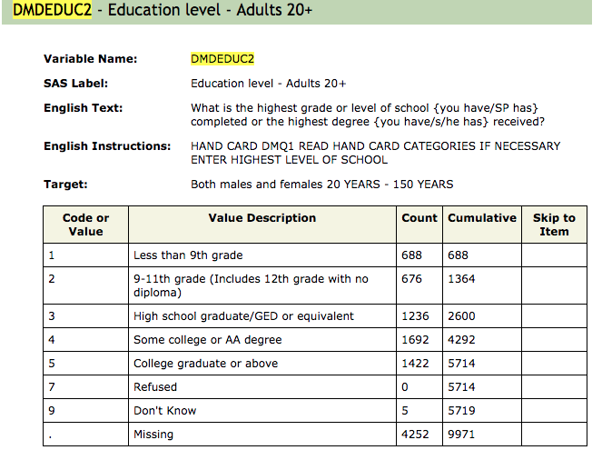

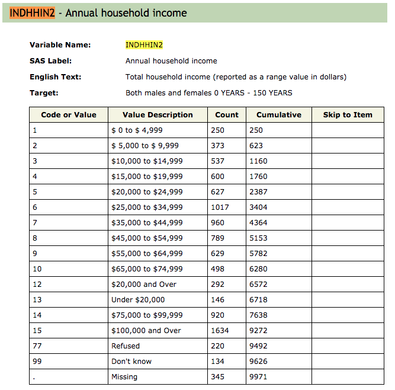

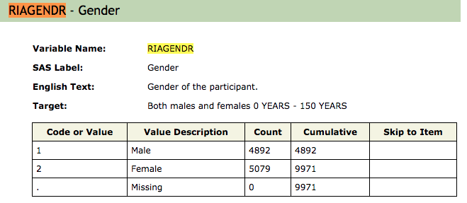

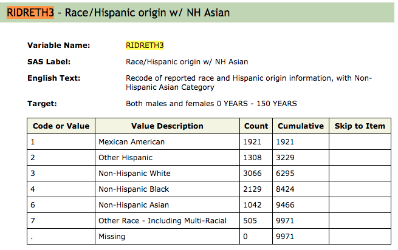

information from: https://wwwn.cdc.gov/Nchs/Nhanes/2015-2016/DEMO_I.htm#RIDAGEYR

# DGP

We import the data and choose the desired variables to create a data set. Meanwhile dealing with the missing values.

```r
library(readxl)
library(dplyr)
```

```r
library(tidyr)
library(ggplot2)
datap <- read_excel('DEMO_I.XLSX')
subdata <- datap %>% select(WTMEC2YR, DMDEDUC2, INDHHIN2, RIAGENDR, RIDRETH3, RIDAGEYR)
numdata <- as.data.frame(subdata)
cleaned_data <- drop_na(numdata)
ind <- which(cleaned_data$WTMEC2YR == 0.000)
cleaned_data <- cleaned_data[-ind,]
```

This table shows the initially descriptive statistics.

```r
summary(numdata)
```

```
##     WTMEC2YR         DMDEDUC2        INDHHIN2        RIAGENDR
##  Min.   :     0   Min.   :1.000   Min.   : 1.00   Min.   :1.000
##  1st Qu.: 12593   1st Qu.:3.000   1st Qu.: 6.00   1st Qu.:1.000
##  Median : 20267   Median :4.000   Median : 8.00   Median :2.000
##  Mean   : 31644   Mean   :3.446   Mean   :11.43   Mean   :1.509
##  3rd Qu.: 33627   3rd Qu.:5.000   3rd Qu.:14.00   3rd Qu.:2.000
##  Max.   :242387   Max.   :9.000   Max.   :99.00   Max.   :2.000
##                   NA's   :3996    NA's   :330
##     RIDRETH3        RIDAGEYR
##  Min.   :1.000   Min.   : 0.00
##  1st Qu.:2.000   1st Qu.: 9.00
##  Median :3.000   Median :27.00
##  Mean   :3.216   Mean   :31.82
##  3rd Qu.:4.000   3rd Qu.:53.00
##  Max.   :7.000   Max.   :80.00
##
```

Below is the table which presents distribution of each independent variable.

depression(WTMEC2YR)

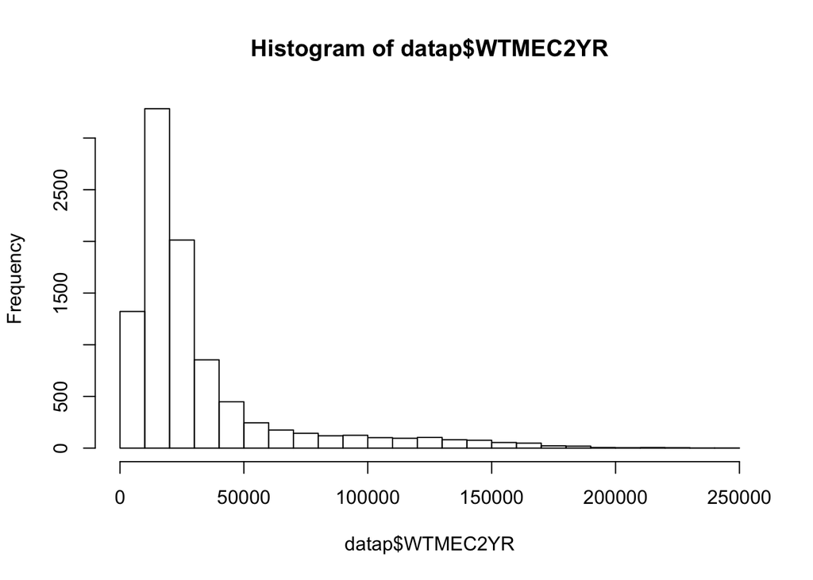

```r
hist(datap$WTMEC2YR, breaks=30)
```

education level(DMDEDUC2), household income(INDHHIN2), gender(RIAGENDR), race(RIDRETH3)

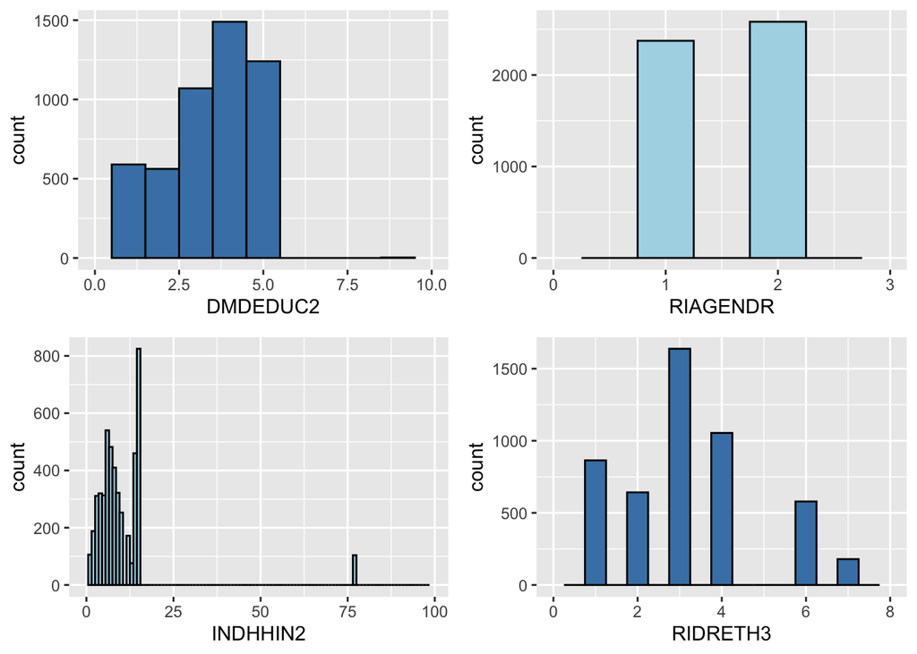

```r
plotedu <- ggplot(cleaned_data, aes(x = DMDEDUC2))+
                    geom_bar(color="black", fill="steelblue", stat='bin',  binwidth=1)+
                    xlim(0,10)
plotinc <- ggplot(cleaned_data, aes(x = INDHHIN2))+
  geom_bar(color="black", fill="lightblue", stat='bin',  binwidth=1)+
  xlim(0,99)
plotgen <- ggplot(cleaned_data, aes(x = RIAGENDR))+
                    geom_bar(color="black", fill="lightblue", stat='bin', binwidth=0.5)+
                    xlim(0,3)
plotrace <- ggplot(cleaned_data, aes(x = RIDRETH3))+
  geom_bar(color="black", fill="steelblue", stat='bin', binwidth=0.5)+
  xlim(0,8)
source("http://peterhaschke.com/Code/multiplot.R")
multiplot(plotedu, plotinc, plotgen, plotrace, cols=2)
```

Below is the table which implies the relationship between each independent variable and depression.

education level(DMDEDUC2), household income(INDHHIN2), gender(RIAGENDR), race(RIDRETH3)

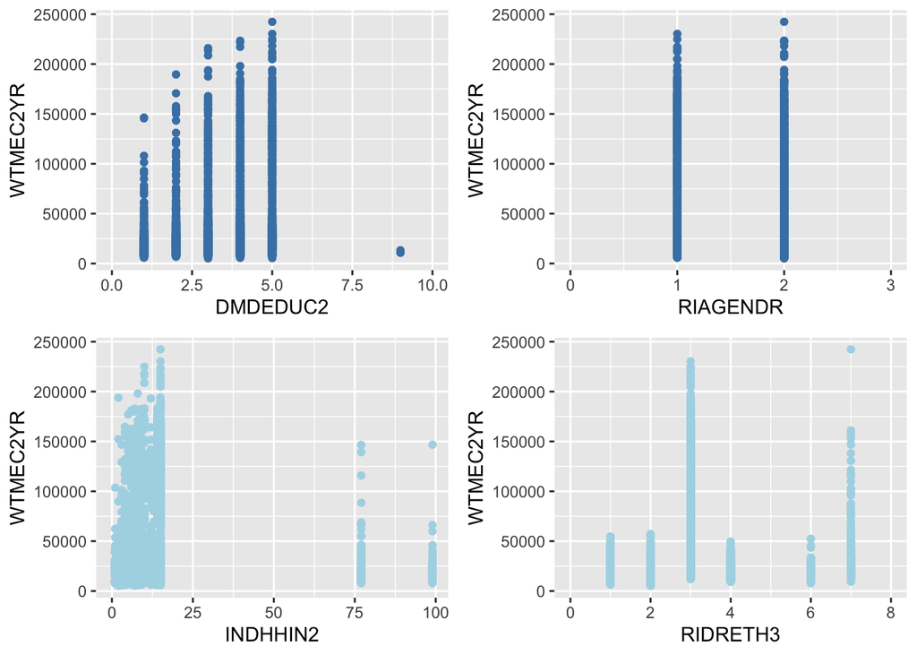

```r
plotedu2 <- ggplot(cleaned_data, aes(x = DMDEDUC2, y=WTMEC2YR))+
  geom_point(color="steelblue")+
  xlim(0,10)
plotinc2 <- ggplot(cleaned_data, aes(x = INDHHIN2, y=WTMEC2YR))+
  geom_point(color="lightblue")+
  xlim(0,99)
plotgen2 <- ggplot(cleaned_data, aes(x = RIAGENDR, y=WTMEC2YR))+
  geom_point(color="steelblue")+
  xlim(0,3)
plotrace2 <- ggplot(cleaned_data, aes(x = RIDRETH3, y=WTMEC2YR))+
  geom_point(color="lightblue")+
  xlim(0,8)
source("http://peterhaschke.com/Code/multiplot.R")
multiplot(plotedu2, plotinc2, plotgen2, plotrace2, cols=2)
```

age(RIDAGEYR)

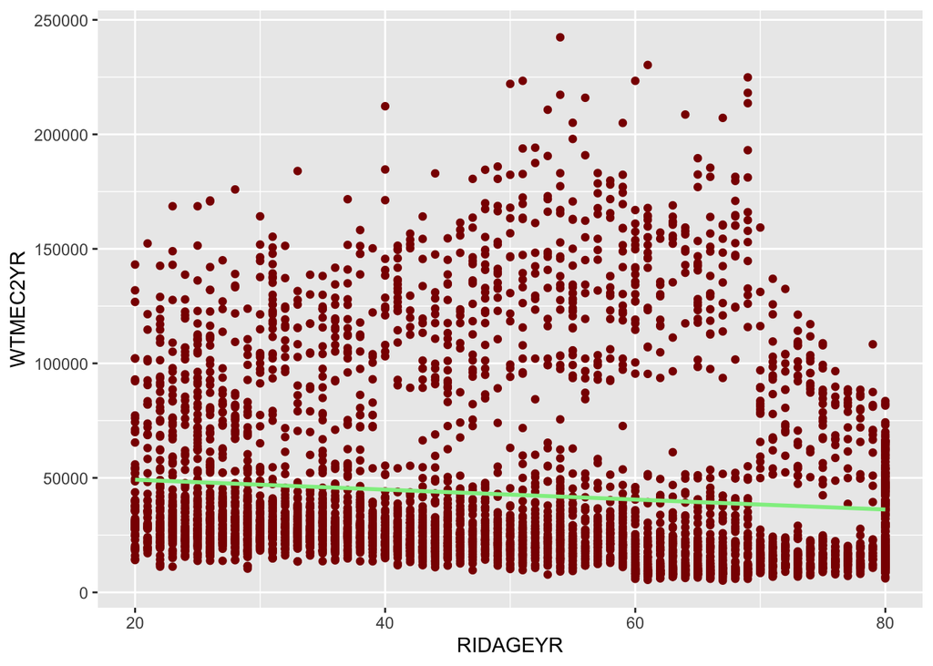

```r
ggplot(cleaned_data, aes(x=RIDAGEYR, y=WTMEC2YR)) +
  geom_point(col='darkred') +
  geom_smooth(method="lm", se=F, col='lightgreen')
```

# Initial regression

We first use adjusted R^2 to determine whether the variable should be included. That is, if adjusted R^2 is larger while adding a variable, it implies that variable has explanatory power. One thing needs to be noticed is that even though gender has decreased R^2 value, it is very little. Since gender has been demonstrated as an important factor in the papers I have read, I decide to keep this variable here. The follows are the procedures:

```r
regressionpro1 <- lm(WTMEC2YR ~ INDHHIN2, data=cleaned_data)
summary(regressionpro1)
```

```
##
## Call:
## lm(formula = WTMEC2YR ~ INDHHIN2, data = cleaned_data)
##
## Residuals:
##    Min     1Q Median     3Q    Max
## -38734 -24272 -16634   3638 199422
##
## Coefficients:
##             Estimate Std. Error t value Pr(>|t|)
## (Intercept) 42337.83     719.98  58.804   <2e-16 ***
## INDHHIN2       41.77      37.86   1.103     0.27
## ---
## Signif. codes:  0 '***' 0.001 '**' 0.01 '*' 0.05 '.' 0.1 ' ' 1
##
## Residual standard error: 40460 on 4954 degrees of freedom
## Multiple R-squared:  0.0002457,  Adjusted R-squared:  4.392e-05
## F-statistic: 1.218 on 1 and 4954 DF,  p-value: 0.2699
```

```r
regressionpro2 <- lm(WTMEC2YR ~ DMDEDUC2+INDHHIN2, data=cleaned_data)
summary(regressionpro2)
```

```
##
## Call:
## lm(formula = WTMEC2YR ~ DMDEDUC2 + INDHHIN2, data = cleaned_data)
##
## Residuals:
##    Min     1Q Median     3Q    Max
## -77178 -25270 -12565   7345 186974
##
## Coefficients:
##              Estimate Std. Error t value Pr(>|t|)
## (Intercept) 14675.913   1602.759   9.157   <2e-16 ***
## DMDEDUC2     8139.681    425.004  19.152   <2e-16 ***
## INDHHIN2        2.566     36.590   0.070    0.944
## ---
## Signif. codes:  0 '***' 0.001 '**' 0.01 '*' 0.05 '.' 0.1 ' ' 1
##
## Residual standard error: 39040 on 4953 degrees of freedom
## Multiple R-squared:  0.06918,    Adjusted R-squared:  0.0688
## F-statistic: 184.1 on 2 and 4953 DF,  p-value: < 2.2e-16
```

```r
regressionpro3 <- lm(WTMEC2YR ~ DMDEDUC2+INDHHIN2+RIAGENDR, data=cleaned_data)
summary(regressionpro3)
```

```
##
## Call:
## lm(formula = WTMEC2YR ~ DMDEDUC2 + INDHHIN2 + RIAGENDR, data = cleaned_data)
##
## Residuals:
##    Min     1Q Median     3Q    Max
## -77183 -25267 -12569   7341 186977
##
## Coefficients:
##              Estimate Std. Error t value Pr(>|t|)
## (Intercept) 14687.626   2298.122   6.391  1.8e-10 ***
## DMDEDUC2     8139.766    425.216  19.143  < 2e-16 ***
## INDHHIN2        2.567     36.594   0.070    0.944
## RIAGENDR       -7.900   1110.647  -0.007    0.994
## ---
## Signif. codes:  0 '***' 0.001 '**' 0.01 '*' 0.05 '.' 0.1 ' ' 1
##
## Residual standard error: 39040 on 4952 degrees of freedom
## Multiple R-squared:  0.06918,    Adjusted R-squared:  0.06861
## F-statistic: 122.7 on 3 and 4952 DF,  p-value: < 2.2e-16
```

```r
regressionpro4 <- lm(WTMEC2YR ~ DMDEDUC2+INDHHIN2+RIAGENDR+RIDRETH3, data=cleaned_data)
summary(regressionpro4)
```

```
##
## Call:
## lm(formula = WTMEC2YR ~ DMDEDUC2 + INDHHIN2 + RIAGENDR + RIDRETH3,
##     data = cleaned_data)
##
## Residuals:
##    Min     1Q Median     3Q    Max
## -88254 -24576 -13041   8539 195742
##
## Coefficients:
##              Estimate Std. Error t value Pr(>|t|)
## (Intercept) 20637.045   2420.124   8.527  < 2e-16 ***
## DMDEDUC2     9039.697    439.685  20.559  < 2e-16 ***
## INDHHIN2        5.716     36.395   0.157    0.875
## RIAGENDR     -354.678   1105.518  -0.321    0.748
## RIDRETH3    -2652.504    354.863  -7.475  9.1e-14 ***
## ---
## Signif. codes:  0 '***' 0.001 '**' 0.01 '*' 0.05 '.' 0.1 ' ' 1
##
## Residual standard error: 38830 on 4951 degrees of freedom
## Multiple R-squared:  0.07957,    Adjusted R-squared:  0.07882
## F-statistic:   107 on 4 and 4951 DF,  p-value: < 2.2e-16
```

```r
regressionpro <- lm(WTMEC2YR ~ DMDEDUC2+INDHHIN2+RIAGENDR+RIDRETH3+RIDAGEYR, data=cleaned_data)
summary(regressionpro)
```

```
##
## Call:
## lm(formula = WTMEC2YR ~ DMDEDUC2 + INDHHIN2 + RIAGENDR + RIDRETH3 +
##     RIDAGEYR, data = cleaned_data)
##
## Residuals:
##    Min     1Q Median     3Q    Max
## -82673 -24576 -13118   8335 196898
##
## Coefficients:
##              Estimate Std. Error t value Pr(>|t|)
## (Intercept) 28669.472   3014.642   9.510  < 2e-16 ***
## DMDEDUC2     8786.796    442.510  19.857  < 2e-16 ***
## INDHHIN2        7.844     36.329   0.216    0.829
## RIAGENDR     -480.594   1103.784  -0.435    0.663
## RIDRETH3    -2672.322    354.218  -7.544 5.38e-14 ***
## RIDAGEYR     -140.088     31.457  -4.453 8.64e-06 ***
## ---
## Signif. codes:  0 '***' 0.001 '**' 0.01 '*' 0.05 '.' 0.1 ' ' 1
##
## Residual standard error: 38760 on 4950 degrees of freedom
## Multiple R-squared:  0.08324,    Adjusted R-squared:  0.08231
## F-statistic: 89.89 on 5 and 4950 DF,  p-value: < 2.2e-16
```

The estimates of the slope coefficients represent when one unit increase in independent variable, how many estimated value increase in dependent variable.

# Complete Regression Model

There are two main directions here: determining the left/right hand side should use log or not.

left hand side(LHS)  
We can determine if we should transform dependent variable by the distribution of residuals.

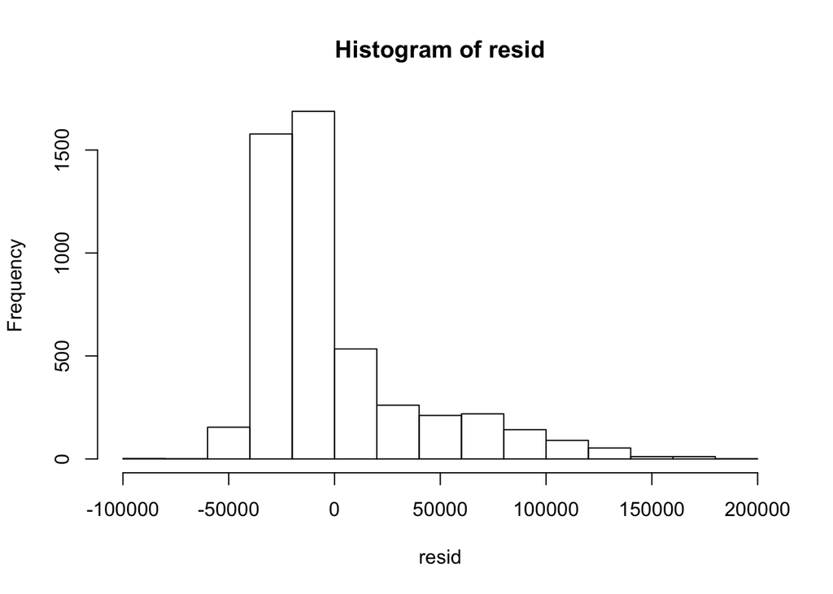

```r
resid <- regressionpro$residuals
hist(resid)
```

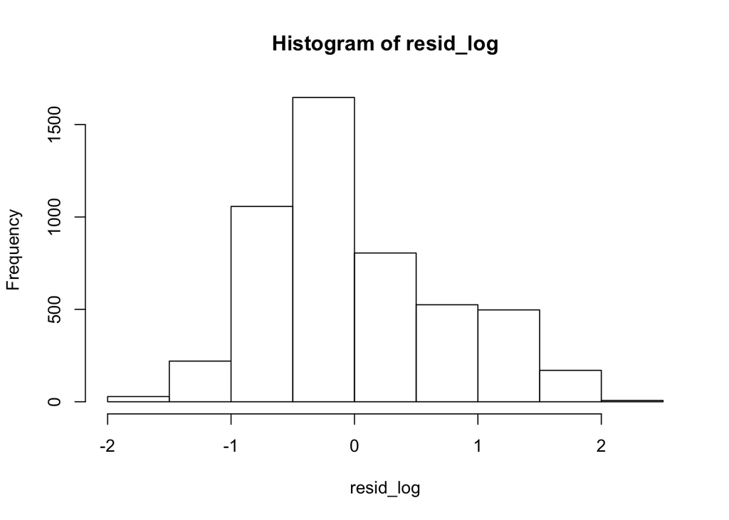

```r
regressionpro_log <- lm(log(WTMEC2YR) ~ DMDEDUC2+INDHHIN2+RIAGENDR+RIDRETH3+RIDAGEYR, data=cleaned_data)
resid_log <- regressionpro_log$residuals
hist(resid_log)
```

When we compare the two table, we can find the distribution of residuals with transformed model is more normal. Consequently, it would be better if we use log level model in LHS.

right hand side(RHS)  
Since we know that education level and household income are quantitative variables, we try to compare them with log and original model.

```r
regressionpro_le <- lm(log(WTMEC2YR) ~ log(DMDEDUC2)+INDHHIN2+RIAGENDR+RIDRETH3+RIDAGEYR, data=cleaned_data)
summary(regressionpro_le)
```

```
##
## Call:
## lm(formula = log(WTMEC2YR) ~ log(DMDEDUC2) + INDHHIN2 + RIAGENDR +
##     RIDRETH3 + RIDAGEYR, data = cleaned_data)
##
## Residuals:
##     Min      1Q  Median      3Q     Max
## -1.8842 -0.5159 -0.1704  0.4755  2.1315
##
## Coefficients:
##                 Estimate Std. Error t value Pr(>|t|)
## (Intercept)    1.030e+01  5.565e-02 185.071  < 2e-16 ***
## log(DMDEDUC2)  4.420e-01  2.183e-02  20.245  < 2e-16 ***
## INDHHIN2      -8.286e-05  6.871e-04  -0.121    0.904
## RIAGENDR       2.683e-02  2.088e-02   1.285    0.199
## RIDRETH3      -3.053e-02  6.699e-03  -4.557 5.32e-06 ***
## RIDAGEYR      -8.376e-03  5.964e-04 -14.044  < 2e-16 ***
## ---
## Signif. codes:  0 '***' 0.001 '**' 0.01 '*' 0.05 '.' 0.1 ' ' 1
##
## Residual standard error: 0.7332 on 4950 degrees of freedom
## Multiple R-squared:  0.1258, Adjusted R-squared:  0.1249
## F-statistic: 142.5 on 5 and 4950 DF,  p-value: < 2.2e-16
```

```r
regressionpro_li <- lm(log(WTMEC2YR) ~ DMDEDUC2+log(INDHHIN2)+RIAGENDR+RIDRETH3+RIDAGEYR, data=cleaned_data)
summary(regressionpro_li)
```

```
##
## Call:
## lm(formula = log(WTMEC2YR) ~ DMDEDUC2 + log(INDHHIN2) + RIAGENDR +
##     RIDRETH3 + RIDAGEYR, data = cleaned_data)
##
## Residuals:
##     Min      1Q  Median      3Q     Max
## -1.8898 -0.5166 -0.1510  0.4753  2.1134
##
## Coefficients:
##                 Estimate Std. Error t value Pr(>|t|)
## (Intercept)   10.0525620  0.0615106 163.428  < 2e-16 ***
## DMDEDUC2       0.1486020  0.0085689  17.342  < 2e-16 ***
## log(INDHHIN2)  0.1109051  0.0139731   7.937 2.54e-15 ***
## RIAGENDR       0.0284580  0.0208063   1.368    0.171
## RIDRETH3      -0.0302000  0.0066746  -4.525 6.19e-06 ***
## RIDAGEYR      -0.0083776  0.0005934 -14.117  < 2e-16 ***
## ---
## Signif. codes:  0 '***' 0.001 '**' 0.01 '*' 0.05 '.' 0.1 ' ' 1
##
## Residual standard error: 0.7303 on 4950 degrees of freedom
## Multiple R-squared:  0.1328, Adjusted R-squared:  0.132
## F-statistic: 151.7 on 5 and 4950 DF,  p-value: < 2.2e-16
```

```r
regressionpro_ll <- lm(log(WTMEC2YR) ~ log(DMDEDUC2)+log(INDHHIN2)+RIAGENDR+RIDRETH3+RIDAGEYR, data=cleaned_data)
summary(regressionpro_ll)
```

```
##
## Call:
## lm(formula = log(WTMEC2YR) ~ log(DMDEDUC2) + log(INDHHIN2) +
##     RIAGENDR + RIDRETH3 + RIDAGEYR, data = cleaned_data)
##
## Residuals:
##     Min      1Q  Median      3Q     Max
## -1.8551 -0.5138 -0.1593  0.4833  2.0561
##
## Coefficients:
##                 Estimate Std. Error t value Pr(>|t|)
## (Intercept)   10.0907617  0.0605072 166.769  < 2e-16 ***
## log(DMDEDUC2)  0.4025415  0.0221881  18.142  < 2e-16 ***
## log(INDHHIN2)  0.1136275  0.0138707   8.192 3.24e-16 ***
## RIAGENDR       0.0308445  0.0207442   1.487    0.137
## RIDRETH3      -0.0313373  0.0066541  -4.709 2.55e-06 ***
## RIDAGEYR      -0.0081405  0.0005931 -13.725  < 2e-16 ***
## ---
## Signif. codes:  0 '***' 0.001 '**' 0.01 '*' 0.05 '.' 0.1 ' ' 1
##
## Residual standard error: 0.7283 on 4950 degrees of freedom
## Multiple R-squared:  0.1375, Adjusted R-squared:  0.1366
## F-statistic: 157.8 on 5 and 4950 DF,  p-value: < 2.2e-16
```

The outcome implies that when both of the two variables add to the model, the estimated values are improved and t-stat demonstrates they are statistical significantly now. Therefor, we should use log transformed model for the two variables. So, the final regression is log(WTMEC2YR) = log(DMDEDUC2) + log(INDHHIN2) + RIAGENDR+RIDRETH3+RIDAGEYR.

Here, maybe just for fun, let us take a look for dummy variable. We already know that gender is intercept dummy variable but we are curious if it is also slope dummy. So, we make education level as interaction term to see the relationship between gender and depression would be affected by the relationship between gender and education level.

```r
cleaned_data$RIAGENDR[which(cleaned_data$RIAGENDR == '2' )] <- 0
cleaned_data$RIAGENDR_edu <- cleaned_data$RIAGENDR * cleaned_data$DMDEDUC2
regressionpro_slopdum <- lm(log(WTMEC2YR) ~ log(DMDEDUC2)+log(INDHHIN2)+RIAGENDR+RIDRETH3+RIDAGEYR+RIAGENDR_edu, data=cleaned_data)
summary(regressionpro_slopdum)
```

```
##
## Call:
## lm(formula = log(WTMEC2YR) ~ log(DMDEDUC2) + log(INDHHIN2) +
##     RIAGENDR + RIDRETH3 + RIDAGEYR + RIAGENDR_edu, data = cleaned_data)
##
## Residuals:
##     Min      1Q  Median      3Q     Max
## -1.8623 -0.5132 -0.1603  0.4821  2.0506
##
## Coefficients:
##                 Estimate Std. Error t value Pr(>|t|)
## (Intercept)   10.1325811  0.0568262 178.308  < 2e-16 ***
## log(DMDEDUC2)  0.4176371  0.0288690  14.467  < 2e-16 ***
## log(INDHHIN2)  0.1138757  0.0138745   8.208 2.85e-16 ***
## RIAGENDR       0.0123096  0.0567249   0.217    0.828
## RIDRETH3      -0.0311790  0.0066571  -4.684 2.90e-06 ***
## RIDAGEYR      -0.0081093  0.0005943 -13.644  < 2e-16 ***
## RIAGENDR_edu  -0.0125560  0.0153612  -0.817    0.414
## ---
## Signif. codes:  0 '***' 0.001 '**' 0.01 '*' 0.05 '.' 0.1 ' ' 1
##
## Residual standard error: 0.7284 on 4949 degrees of freedom
## Multiple R-squared:  0.1376, Adjusted R-squared:  0.1366
## F-statistic: 131.6 on 6 and 4949 DF,  p-value: < 2.2e-16
```

```r
fem_less <- 0.4176371-0.0125560
fem_less
```

```
## [1] 0.4050811
```